# Picture and a Brief Biography

I’m originally from Minnesota, but a particularly brutal winter about eight years ago convinced me to head west. I consider myself a Seattleite now, but my Minnesota accent still comes out every now and then.

After completing a bachelor’s degree in Political Science and two years of AmeriCorps service, I spent nearly a decade working in healthcare administration before quitting my job to go back to school.

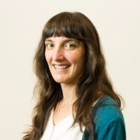

## My Home Department

I’m a second-year student in the [Master of Science in Information Management](https://ischool.uw.edu/programs/msim) program in the [Information School](https://ischool.uw.edu/).

## Interest In The Course And What Scares You About It

I have exposure to some data science concepts and practices through my iSchool coursework and I’m interested to see these applied in different settings. I’m especially interested in ethical challenges that might arise using data science techniques in the public and non-profit sectors. I’ve used R before, but I’ll also be working in Python this quarter so I’m a little worried about keeping the languages straight.

## Three Things About Me

- I’m a big WNBA fan (Go Storm!)
- I sew most of my clothes
- I love hiking and backpacking, especially along the coast

## Favorite Quote Joke

> You know, I’m sick of following my dreams, man. I’m just gonna ask where they’re going and hook up with ’em later.

> -*Mitch Hedberg*

## Display Some Data

```r
data("warpbreaks")
```

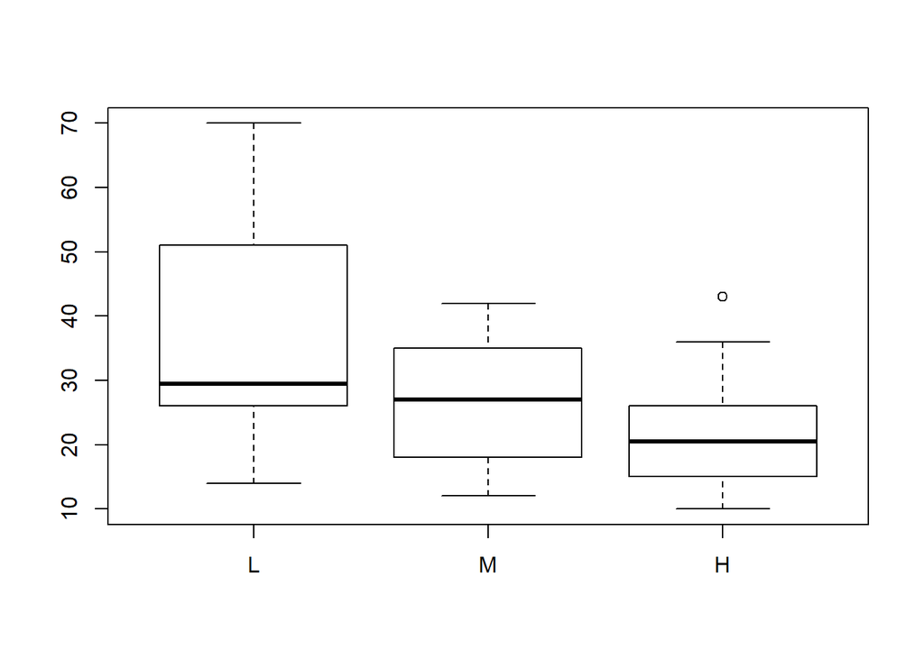

```r
plot(warpbreaks$tension, warpbreaks$breaks)
```